# data.table

Xiaosong Jin

2018-05-01

# 1 data.table

data.table包提供了一个data.frame的高级版本，是一个超高性能处理包，其在处理上代码简介，功能强大，并且效率极高，强烈建议大家使用此包。官方链接：https://github.com/Rdatatable/data.table/wiki  
data.table的语法主要是基于`[]`，其一般格式是：DT[i, j, by]。  
解释：“Take DT, subset rows using i, then calculate j grouped by by.”  
注：以下称data.table为数据表。

# 2 Download And Library

此包被收录在CRAN里面，所以下载它特别方便，只需要使用`install.packages()`即可。

```r
# install.packages("data.table")
library(data.table)
```

# 3 Creating A data.table

构建一个数据表可以用`data.table()`直接构建，也可以将数据框使用`data.table()`去转换为数据表：

```r
set.seed(45L)
DT <- data.table(V1 = c(1L, 2L),
                 V2 = LETTERS[1:3],
                 V3 = round(rnorm(4), 4),
                 V4 = 1:12)
DT
```

```
##     V1 V2      V3 V4
##  1:  1  A  0.3408  1
##  2:  2  B -0.7033  2
##  3:  1  C -0.3795  3
##  4:  2  A -0.7460  4
##  5:  1  B  0.3408  5
##  6:  2  C -0.7033  6
##  7:  1  A -0.3795  7
##  8:  2  B -0.7460  8
##  9:  1  C  0.3408  9
## 10:  2  A -0.7033 10
## 11:  1  B -0.3795 11
## 12:  2  C -0.7460 12
```

```r
set.seed(45L)
DF <- data.frame(V1 = c(1L, 2L),
                 V2 = LETTERS[1:3],
                 V3 = round(rnorm(4), 4),
                 V4 = 1:12)

DF_T <- data.table(DF); DF_T
```

```
##     V1 V2      V3 V4
##  1:  1  A  0.3408  1
##  2:  2  B -0.7033  2
##  3:  1  C -0.3795  3
##  4:  2  A -0.7460  4
##  5:  1  B  0.3408  5
##  6:  2  C -0.7033  6
##  7:  1  A -0.3795  7
##  8:  2  B -0.7460  8
##  9:  1  C  0.3408  9
## 10:  2  A -0.7033 10
## 11:  1  B -0.3795 11
## 12:  2  C -0.7460 12
```

# 4 Subsetting Rows Using i

使用DT[i, j, by]中的i进行子集的选取。

```r
# DT[3:5]
DT[3:5, ]
```

```
##    V1 V2      V3 V4
## 1:  1  C -0.3795  3
## 2:  2  A -0.7460  4
## 3:  1  B  0.3408  5
```

```r
# DT[V2 == "A"]
DT[V2 == "A", ]
```

```
##    V1 V2      V3 V4
## 1:  1  A  0.3408  1
## 2:  2  A -0.7460  4
## 3:  1  A -0.3795  7
## 4:  2  A -0.7033 10
```

```r
# DT[V2 %in% c("A", "C")]
DT[V2 %in% c("A", "C"), ]
```

```
##    V1 V2      V3 V4
## 1:  1  A  0.3408  1
## 2:  1  C -0.3795  3
## 3:  2  A -0.7460  4
## 4:  2  C -0.7033  6
## 5:  1  A -0.3795  7
## 6:  1  C  0.3408  9
## 7:  2  A -0.7033 10
## 8:  2  C -0.7460 12
```

# 5 Manipulating on Columns in j

对列进行操作的时候，需要注意返回的类型（向量还是数据表）。  
如果想返回向量，可以使用`DT[, j]`、`DT[[idx]]`或`DT[["j"]]`。  
如果想返回数据表，可以使用`DT[, "j"]`、`DT[, .(j)]`或`DT[, idx]`。  
注：上述针对的是某一列，并且均推荐使用第一种操作方式。  
对多列进行操作时，必不可少的就是`.()`符号，其相当于`list()`

## 5.1 **vector**

```r
DT[, V2]
```

```
##  [1] "A" "B" "C" "A" "B" "C" "A" "B" "C" "A" "B" "C"
```

```r
DT[[2]]
```

```
##  [1] "A" "B" "C" "A" "B" "C" "A" "B" "C" "A" "B" "C"
```

```r
DT[["V2"]]
```

```
##  [1] "A" "B" "C" "A" "B" "C" "A" "B" "C" "A" "B" "C"
```

```r
DT[, !c("V1", "V3", "V4")]
```

```
##     V2
##  1:  A
##  2:  B
##  3:  C
##  4:  A
##  5:  B
##  6:  C
##  7:  A
##  8:  B
##  9:  C
## 10:  A
## 11:  B
## 12:  C
```

```r
DT[, names(DT) %like% "2", with = F]
```

```
##     V2
##  1:  A
##  2:  B
##  3:  C
##  4:  A
##  5:  B
##  6:  C
##  7:  A
##  8:  B
##  9:  C
## 10:  A
## 11:  B
## 12:  C
```

```r
DT[, sum(V1)]
```

```
## [1] 18
```

## 5.2 **data.table_col**

```r
DT[, "V2"]
```

```
##     V2
##  1:  A
##  2:  B
##  3:  C
##  4:  A
##  5:  B
##  6:  C
##  7:  A
##  8:  B
##  9:  C
## 10:  A
## 11:  B
## 12:  C
```

```r
DT[, 2]
```

```
##     V2
##  1:  A
##  2:  B
##  3:  C
##  4:  A
##  5:  B
##  6:  C
##  7:  A
##  8:  B
##  9:  C
## 10:  A
## 11:  B
## 12:  C
```

## 5.3 **data.table_cols**

```r
DT[, .(V2, V3)]
```

```
##     V2      V3
##  1:  A  0.3408
##  2:  B -0.7033
##  3:  C -0.3795
##  4:  A -0.7460
##  5:  B  0.3408
##  6:  C -0.7033
##  7:  A -0.3795
##  8:  B -0.7460
##  9:  C  0.3408
## 10:  A -0.7033
## 11:  B -0.3795
## 12:  C -0.7460
```

```r
DT[, list(V2, V3)]
```

```
##     V2      V3
##  1:  A  0.3408
##  2:  B -0.7033
##  3:  C -0.3795
##  4:  A -0.7460
##  5:  B  0.3408
##  6:  C -0.7033
##  7:  A -0.3795
##  8:  B -0.7460
##  9:  C  0.3408
## 10:  A -0.7033
## 11:  B -0.3795
## 12:  C -0.7460
```

```r
DT[, .(sum(V1), sd(V3))]
```

```
##    V1        V2
## 1: 18 0.4546055
```

```r
DT[, .(Aggregate = sum(V1), Sd.V3 = sd(V3))]
```

```
##    Aggregate     Sd.V3
## 1:        18 0.4546055
```

```r
DT[, .(V1, Sd.V3 = sd(V3))]
```

```
##     V1     Sd.V3
##  1:  1 0.4546055
##  2:  2 0.4546055
##  3:  1 0.4546055
##  4:  2 0.4546055
##  5:  1 0.4546055
##  6:  2 0.4546055
##  7:  1 0.4546055
##  8:  2 0.4546055
##  9:  1 0.4546055
## 10:  2 0.4546055
## 11:  1 0.4546055
## 12:  2 0.4546055
```

```
##  [1] "A" "B" "C" "A" "B" "C" "A" "B" "C" "A" "B" "C"
```

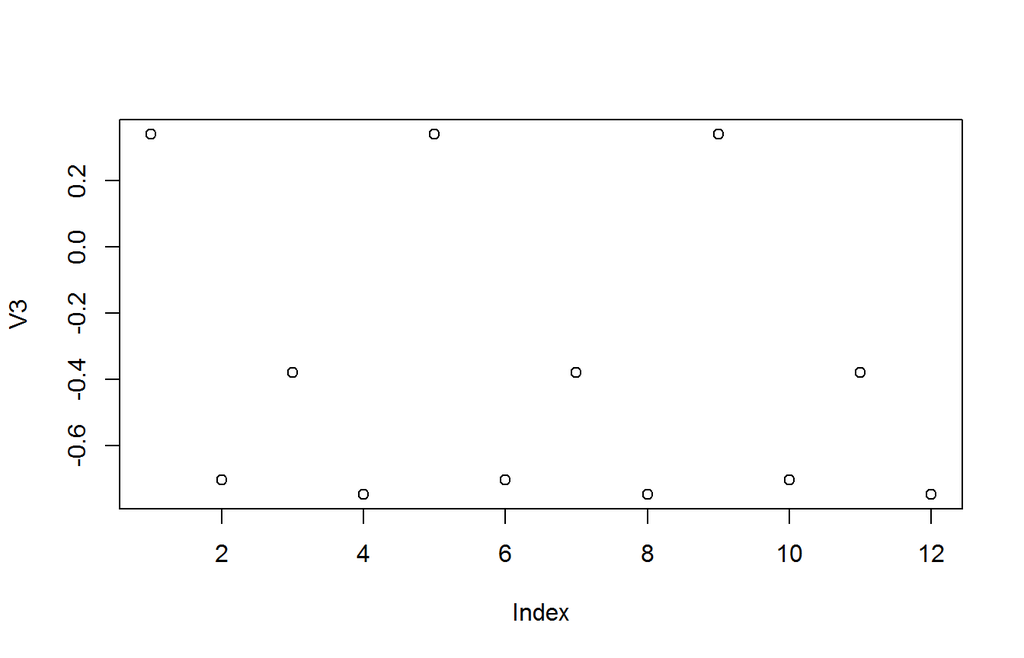

```
##     V1
##  1:  A
##  2:  B
##  3:  C
##  4:  A
##  5:  B
##  6:  C
##  7:  A
##  8:  B
##  9:  C
## 10:  A
## 11:  B
## 12:  C
```

```r
DT[, .(print(V2), plot(V3))]
```

# 6 Doing j by Group

使用DT[i, j, by]中的by对j进行操作。

```r
DT[, .(V4.Sum = sum(V4)), by = V1]
```

```
##    V1 V4.Sum
## 1:  1     36
## 2:  2     42
```

```r
DT[, .(V4.Sum = sum(V4)), by = .(V1, V2)]
```

```
##    V1 V2 V4.Sum
## 1:  1  A      8
## 2:  2  B     10
## 3:  1  C     12
## 4:  2  A     14
## 5:  1  B     16
## 6:  2  C     18
```

```r
DT[, .(V4.Sum = sum(V4)), by = sign(V1-1)]  #列名会被sign填补
```

```
##    sign V4.Sum
## 1:    0     36
## 2:    1     42
```

```r
DT[, .(V4.Sum = sum(V4)), by = .(V1.01 = sign(V1-1))]  #自定义列名
```

```
##    V1.01 V4.Sum
## 1:     0     36
## 2:     1     42
```

```r
DT[, .N, by = V1]  #统计V1列特征值的个数
```

```
##    V1 N
## 1:  1 6
## 2:  2 6
```

# 7 setorder

`setorder()`可以按照一个变量或者多个变量排序，默认的排列方式是升序，如果想要降序，只需要在变量名前面加一个`-`即可。

```r
setorder(DT, V3)
setorder(DT, V3, -V4)
```

# 8 Add/Updat/Del Columns in j

使用`:=`可以对数据的列进行重塑：Updat、Add、Delete。  
注：额外的指定DT <- DT[…]是多余的，以下操作会直接在DT上进行修改。并且后面使用`[]`会代替`DT`使修改后的数据直接返回。

## 8.1 **Updat**

```r
DT[, V1 := round(exp(V1), 2)] []
```

```
##       V1 V2      V3 V4
##  1: 7.39  C -0.7460 12
##  2: 7.39  B -0.7460  8
##  3: 7.39  A -0.7460  4
##  4: 7.39  A -0.7033 10
##  5: 7.39  C -0.7033  6
##  6: 7.39  B -0.7033  2
##  7: 2.72  B -0.3795 11
##  8: 2.72  A -0.3795  7
##  9: 2.72  C -0.3795  3
## 10: 2.72  C  0.3408  9
## 11: 2.72  B  0.3408  5
## 12: 2.72  A  0.3408  1
```

```r
DT[, c("V1", "V2") := .(round(exp(V1), 2), LETTERS[4:6])] []
```

```
##          V1 V2      V3 V4
##  1: 1619.71  D -0.7460 12
##  2: 1619.71  E -0.7460  8
##  3: 1619.71  F -0.7460  4
##  4: 1619.71  D -0.7033 10
##  5: 1619.71  E -0.7033  6
##  6: 1619.71  F -0.7033  2
##  7:   15.18  D -0.3795 11
##  8:   15.18  E -0.3795  7
##  9:   15.18  F -0.3795  3
## 10:   15.18  D  0.3408  9
## 11:   15.18  E  0.3408  5
## 12:   15.18  F  0.3408  1
```

## 8.2 **Add**

```r
DT[, V5 := letters[4:6]] []
```

```
##          V1 V2      V3 V4 V5
##  1: 1619.71  D -0.7460 12  d
##  2: 1619.71  E -0.7460  8  e
##  3: 1619.71  F -0.7460  4  f
##  4: 1619.71  D -0.7033 10  d
##  5: 1619.71  E -0.7033  6  e
##  6: 1619.71  F -0.7033  2  f
##  7:   15.18  D -0.3795 11  d
##  8:   15.18  E -0.3795  7  e
##  9:   15.18  F -0.3795  3  f
## 10:   15.18  D  0.3408  9  d
## 11:   15.18  E  0.3408  5  e
## 12:   15.18  F  0.3408  1  f
```

```r
DT[, c("V6", "V7") := .(sum(V1), mean(V4))] []
```

```
##          V1 V2      V3 V4 V5      V6  V7
##  1: 1619.71  D -0.7460 12  d 9809.34 6.5
##  2: 1619.71  E -0.7460  8  e 9809.34 6.5
##  3: 1619.71  F -0.7460  4  f 9809.34 6.5
##  4: 1619.71  D -0.7033 10  d 9809.34 6.5
##  5: 1619.71  E -0.7033  6  e 9809.34 6.5
##  6: 1619.71  F -0.7033  2  f 9809.34 6.5
##  7:   15.18  D -0.3795 11  d 9809.34 6.5
##  8:   15.18  E -0.3795  7  e 9809.34 6.5
##  9:   15.18  F -0.3795  3  f 9809.34 6.5
## 10:   15.18  D  0.3408  9  d 9809.34 6.5
## 11:   15.18  E  0.3408  5  e 9809.34 6.5
## 12:   15.18  F  0.3408  1  f 9809.34 6.5
```

## 8.3 **Delete**

```r
DT[, V7:= NULL] []
```

```
##          V1 V2      V3 V4 V5      V6
##  1: 1619.71  D -0.7460 12  d 9809.34
##  2: 1619.71  E -0.7460  8  e 9809.34
##  3: 1619.71  F -0.7460  4  f 9809.34
##  4: 1619.71  D -0.7033 10  d 9809.34
##  5: 1619.71  E -0.7033  6  e 9809.34
##  6: 1619.71  F -0.7033  2  f 9809.34
##  7:   15.18  D -0.3795 11  d 9809.34
##  8:   15.18  E -0.3795  7  e 9809.34
##  9:   15.18  F -0.3795  3  f 9809.34
## 10:   15.18  D  0.3408  9  d 9809.34
## 11:   15.18  E  0.3408  5  e 9809.34
## 12:   15.18  F  0.3408  1  f 9809.34
```

```r
DT[, c("V3", "V4") := NULL] []
```

```
##          V1 V2 V5      V6
##  1: 1619.71  D  d 9809.34
##  2: 1619.71  E  e 9809.34
##  3: 1619.71  F  f 9809.34
##  4: 1619.71  D  d 9809.34
##  5: 1619.71  E  e 9809.34
##  6: 1619.71  F  f 9809.34
##  7:   15.18  D  d 9809.34
##  8:   15.18  E  e 9809.34
##  9:   15.18  F  f 9809.34
## 10:   15.18  D  d 9809.34
## 11:   15.18  E  e 9809.34
## 12:   15.18  F  f 9809.34
```

```r
Col.Chosen = c("V5", "V6")
DT[, Col.Chosen := NULL] []  #“Col.Chosen”在这里是一个变量名称，而不是“V5”&“V6”
```

```
##          V1 V2 V5      V6
##  1: 1619.71  D  d 9809.34
##  2: 1619.71  E  e 9809.34
##  3: 1619.71  F  f 9809.34
##  4: 1619.71  D  d 9809.34
##  5: 1619.71  E  e 9809.34
##  6: 1619.71  F  f 9809.34
##  7:   15.18  D  d 9809.34
##  8:   15.18  E  e 9809.34
##  9:   15.18  F  f 9809.34
## 10:   15.18  D  d 9809.34
## 11:   15.18  E  e 9809.34
## 12:   15.18  F  f 9809.34
```

```r
DT[, (Col.Chosen) := NULL] [] #“Col.Chosen”在这里代表“V5”&“V6”
```

```
##          V1 V2
##  1: 1619.71  D
##  2: 1619.71  E
##  3: 1619.71  F
##  4: 1619.71  D
##  5: 1619.71  E
##  6: 1619.71  F
##  7:   15.18  D
##  8:   15.18  E
##  9:   15.18  F
## 10:   15.18  D
## 11:   15.18  E
## 12:   15.18  F
```